# Late-Season VHF Tagging Update

1 October 2025

Author

Eleanor

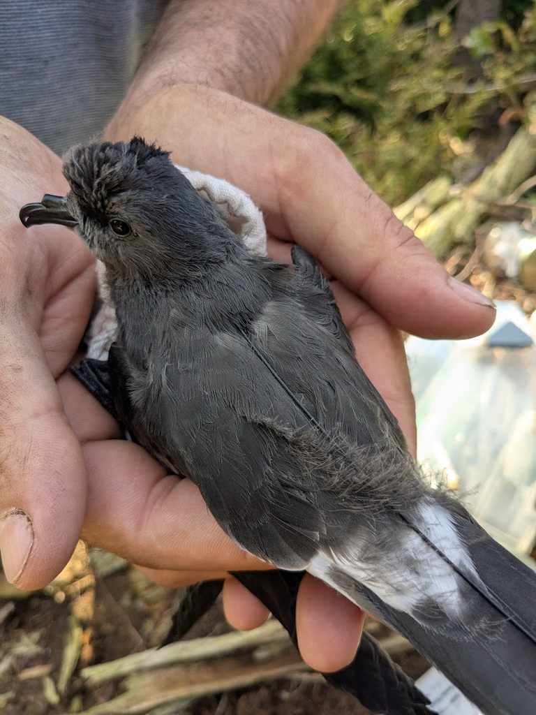

## Highlights

**Note that no data from 2024 is incorporated into this document; these are only results from this year.**

## Tag Deployments

Fledglings: On 22 September, we tagged 10 fledglings on Gull. On 23 September, we tagged 16 fledglings on Baccalieu. On 28 September, we tagged an additional 9 fledglings on Gull. Here is a table of how many tags have been deployed at each site:

| Island | Age Class | # Tags Deployed | Tagging Dates |
| --- | --- | --- | --- |
| Baccalieu | Fledgling | 16 | 2025-09-23 |
| Baccalieu | Pre-breeder | 18 | 2025-07-11 |
| Great | Breeder | 3 | 2025-07-09 |
| Great | Pre-breeder | 17 | 2025-06-22, 2025-07-09, 2025-07-20 |
| Gull | Breeder | 9 | 2025-07-03, 2025-08-10 |
| Gull | Fledgling | 19 | 2025-09-22, 2025-09-28 |
| Gull | Pre-breeder | 13 | 2025-06-16, 2025-06-17, 2025-07-03, 2025-07-07, 2025-07-16, 2025-07-23 |
| Middle Lawn | Pre-breeder | 4 | 2025-06-24, 2025-06-27 |

## Tag Retention

We continue to have much better luck than we did last year with tag retention, and I think the flat-bottomed design of these new tags has made all the difference. It is difficult to estimate tag retention without being very conservative, because we usually cannot tell the difference between birds that have dropped their tags and birds that have departed the area. Since we know now that some pre-breeders are moving fairly widely among colonies, it is probably a good bet that many are leaving the area well before they lose their tags.

Below, I have estimated tag retention based on the period between a bird’s first detection (on the night of tagging) and its last detection from any of our receivers. Birds that were never detected again after tagging (and so were only present on one night) are not included.

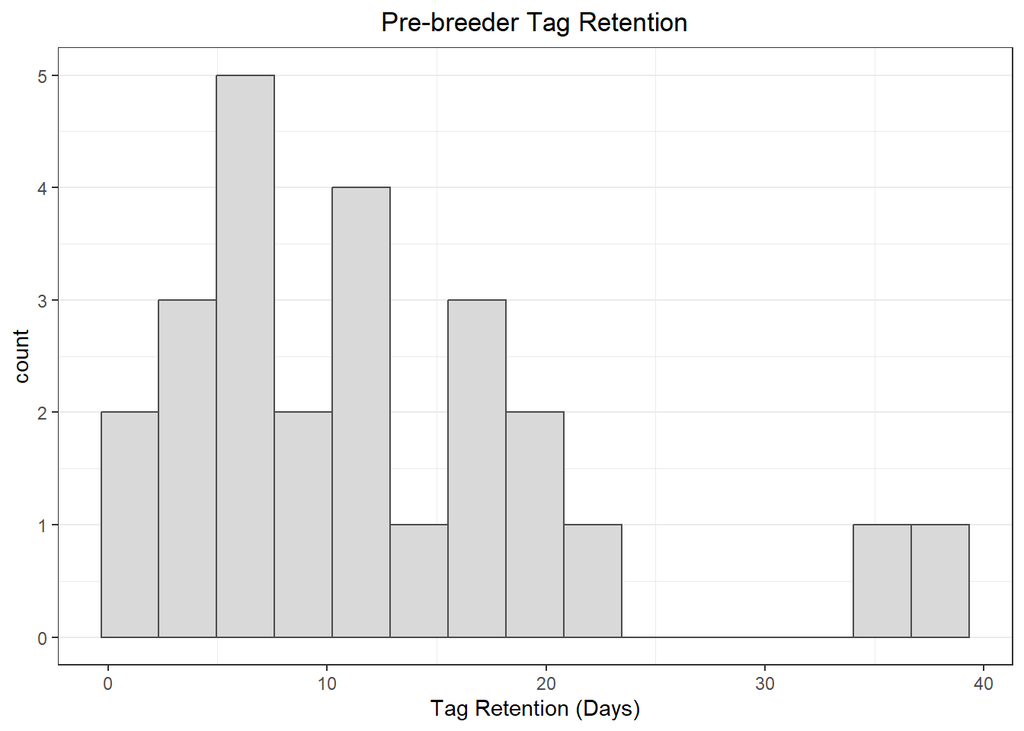

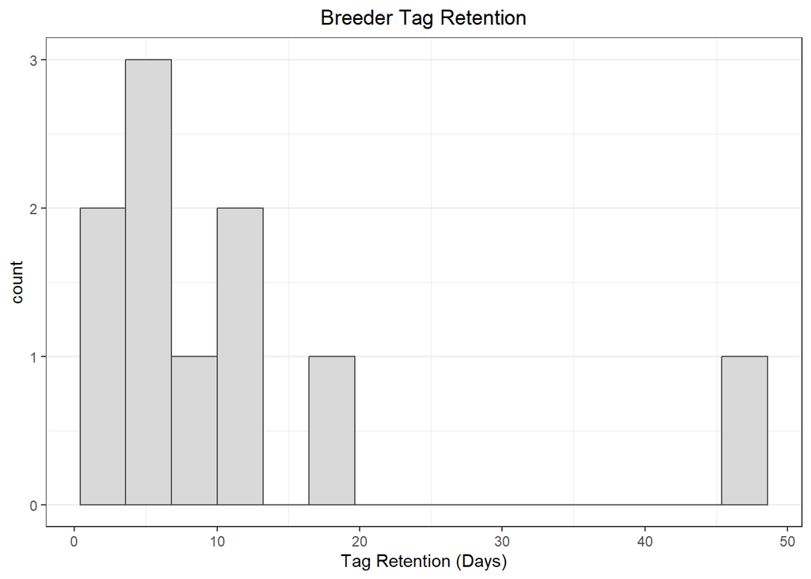

One of our pre-breeders, tagged on Baccalieu, kept its tag for 38 days, and one of the pre-breeders tagged on Gull kept its tag for 35 days. One of our breeding birds from Gull has kept its tag for 47 days, and was last detected on 27 September, so it may still have its tag.

Mean tag retention for pre-breeders was 12.2 days, and median retention was 11 days. For breeders, the mean was 11.9 days, and the median was 7.5. I have the sense that breeding birds lose their tags faster because going in and out of burrows scrapes at the glue; we have recovered a few dropped tags from inside burrows. But the two age classes are surprisingly similar.

## Site Movement Summaries

### Gull Island

6 out of 13 pre-breeders tagged on Gull returned to visit our islands at least once after being tagged. Their movement tracks are shown below:

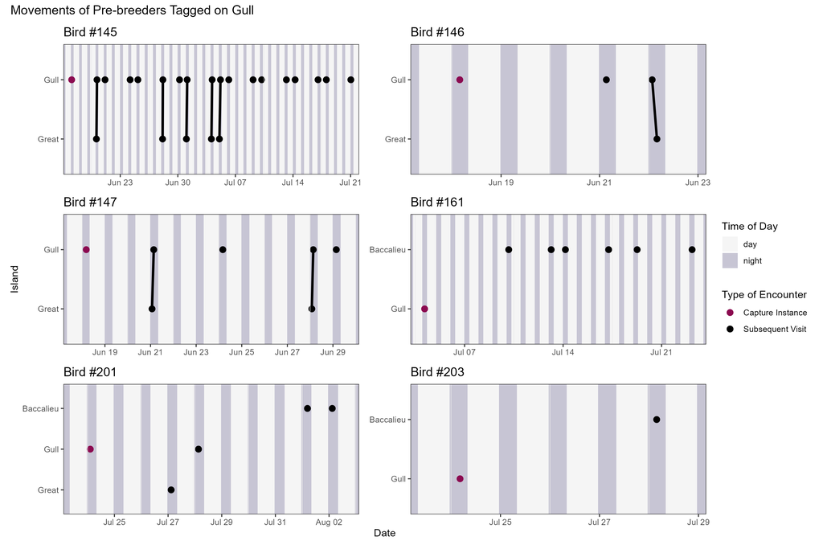

Interestingly, two birds (#161 & #203) only visited Baccalieu. Four out of six visited Great Island at least once, and trips between Gull and Great in the same night were common.

Gull was visited by six out of 17 pre-breeders that were tagged on Great Island, and by six out of 18 pre-breeders tagged on Baccalieu. Of the nine breeding birds tagged on Gull Island, only two were ever detected on Great Island, and those detections appear as brief fly-bys.

### Great Island

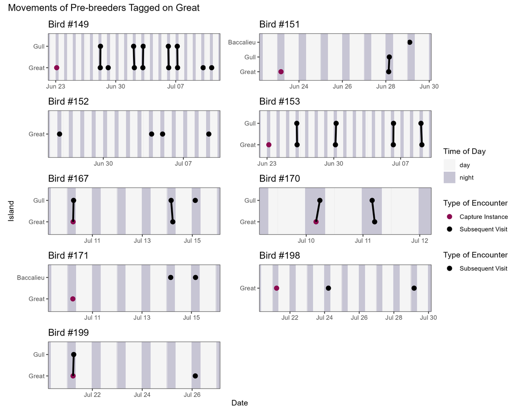

Nine out of 17 pre-breeders tagged on Great Island returned to visit one of our colonies at least once. One of them only visited Baccalieu. Six out of nine visited Gull at least once, and again inter-colony movements were common.

Great Island was visited by four pre-breeders from Gull and four from Baccalieu (and all four of those from Baccalieu were also visitors to Gull). None of the three breeding birds tagged on Great were ever detected at another colony.

### Baccalieu Island

Unfortunately, the wildfire on the Bay du Verde peninsula kept us from making more than one trip to Baccalieu to deploy tags. However, we got a lot of good data from the 18 tags we were able to deploy on our first trip. We left the station unattended for more than two months because of the fire, and I was very happy to find that it never lost power or had any issues in that time.

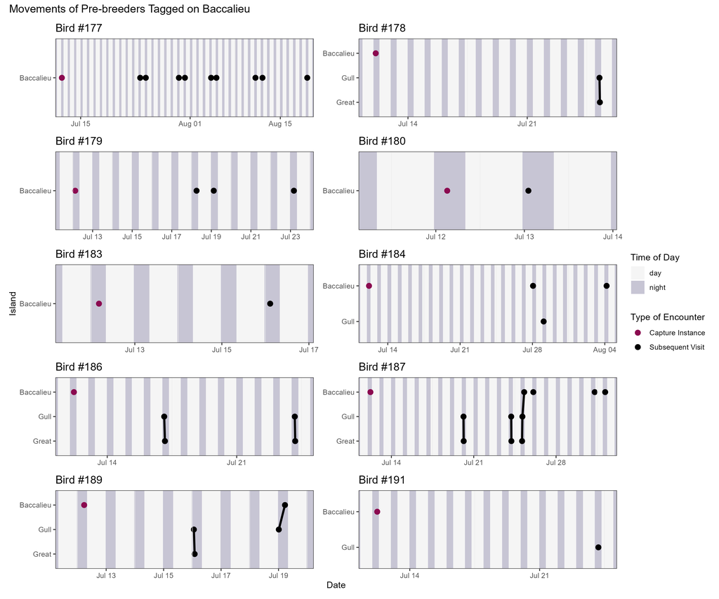

10 out of 18 pre-breeders tagged on Baccalieu returned to visit our islands at least once. Four returned only to Baccalieu, but six visited Witless Bay, and three of those six *only* visited Witless Bay and never returned to Baccalieu.

Impressively, two birds tagged on Baccalieu were detected visiting both Witless Bay and Baccalieu in the same night. In both cases, they started out in Witless Bay, and then traveled quite quickly to Baccalieu—a distance of around 100 km by the shortest route. Records of these movements are shown below. My typical approach for these plots is to represent each individual antenna from each station as a row on the y-axis, with the datetime on the x-axis. Each individual VHF transmission is shown as a point, colored by the power of the received transmission. Therefore, in general, darker points correspond to instances where the bird was closer to the receiving antenna (however, the Baccalieu receiver almost always records transmissions at a higher power level than the Witless Bay receivers—the different models of receiver seem to vary in their thresholds). I have not grouped or filtered these data.

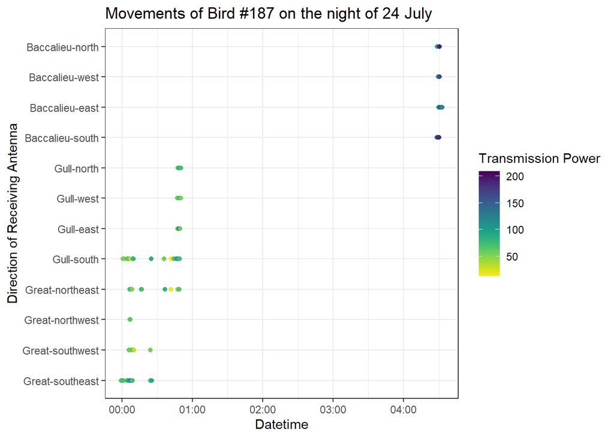

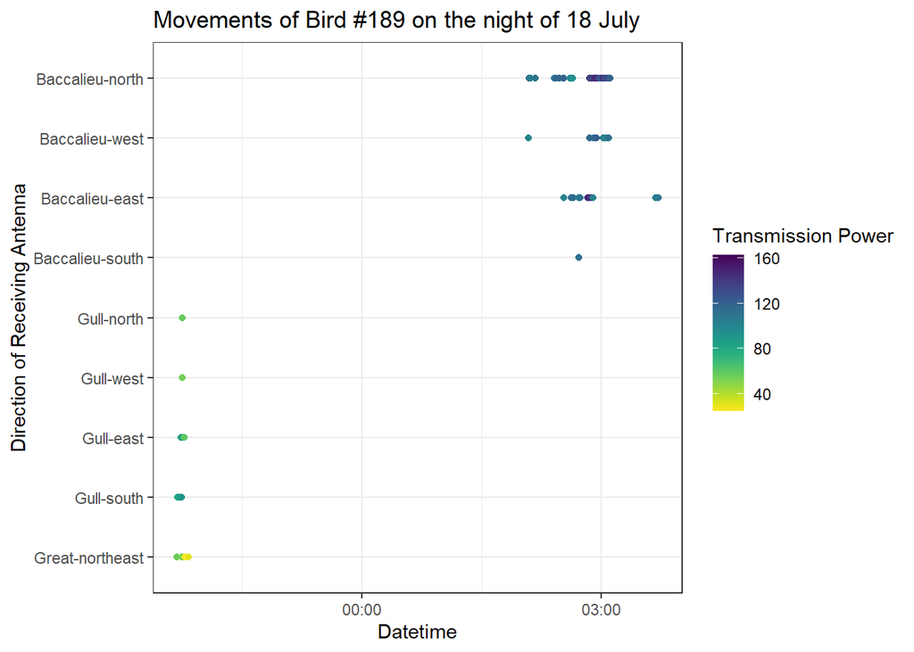

## Colony Attendance Patterns

25 out of 52 pre-breeders (48%) returned to visit at least one of our colonies at least once. This includes 6 out of 13 (46%) birds tagged on Gull, 9 out of 17 (53%) birds tagged on Great, 10 out of 18 (55.5%) birds tagged on Baccalieu, and none of the 4 pre-breeders tagged on Middle Lawn. Note that Middle Lawn does not have its own receiver station. We may still see detections from those Middle Lawn birds as various Motus stations finish their field seasons and upload data (I am especially interested in the station on Miquelon). If we remove the Middle Lawn birds from the pool, our return rate goes from 48% to 52%.

I think our tag retention data suggests that the birds we never hear from again are not simply dropping their tags immediately, but are actually leaving the area. Therefore, it seems that about half of tagged pre-breeders are either visiting these colonies only rarely and briefly, or are turned away from the colonies after the disturbance of being tagged. Since we have observed several cases of tagged birds visiting only once or twice soon after being tagged, then leaving the area, I think the prior case is believable.

In general, pre-breeders spend more of their time on the colonies where they were tagged than on other colonies. Here are boxplots of colony attendance time (as a proportion of total time present at any colony) broken down by colony of capture. Birds that were never detected after their night of capture are not included:

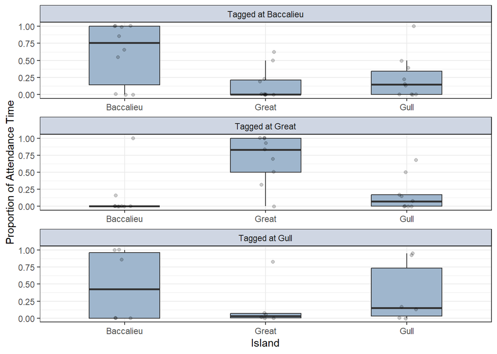

So, while pre-breeders appear to show preference for the colony where they were captured and tagged, that preference is not absolute. Especially notable are a few cases of birds from Gull that clearly preferred Baccalieu, and a few birds from Baccalieu that spent much more of their time in Witless Bay.

One interesting pattern that has emerged is from birds that repeatedly appear for two nights in a row, with several nights between visits. Birds #145, #177, and #149 are good examples from the figures above. Dave suggested that these individuals might be arriving in one night, spending the day inside a burrow, then emerging the next night.

## Fledglings

So far, we have tagged 19 fledglings on Gull Island and 16 on Baccalieu. On Gull Island, we split the tags between the “light” side of the island, which faces the lights of the town of Witless Bay, and the “dark” side, which faces only open ocean. Here are maps of the burrow locations:

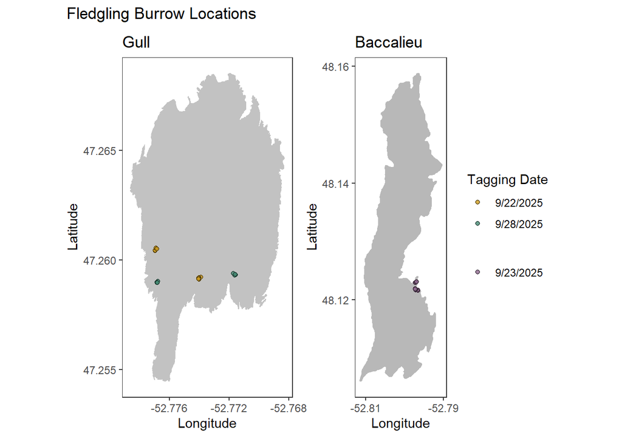

Of the ten fledglings we tagged on Gull Island on 22 September, 9 had fledged when we returned to Gull on the 28th. The 10th was still in its burrow. We have not yet returned to Baccalieu to check on those fledglings. Of the nine Gull Island fledglings that have departed, one bird fledged per night on the 22nd, 23rd, and 24th. Three birds fledged on the night of the 25th, and three fledged on the night of the 27th.

We try to tag fledglings in burrows where, when the birds are in their burrows, their tags are still detected on at least one antenna. This allows us to tell when the birds are inside or outside of their burrows; when outside, transmission power typically spikes, and transmissions are received on additional antennas. For example, here are the transmissions received from bird #214 on the night that it fledged. In this case, transmission power is graphed on the y-axis, and the figure is broken down by the four Gull Island antennas.

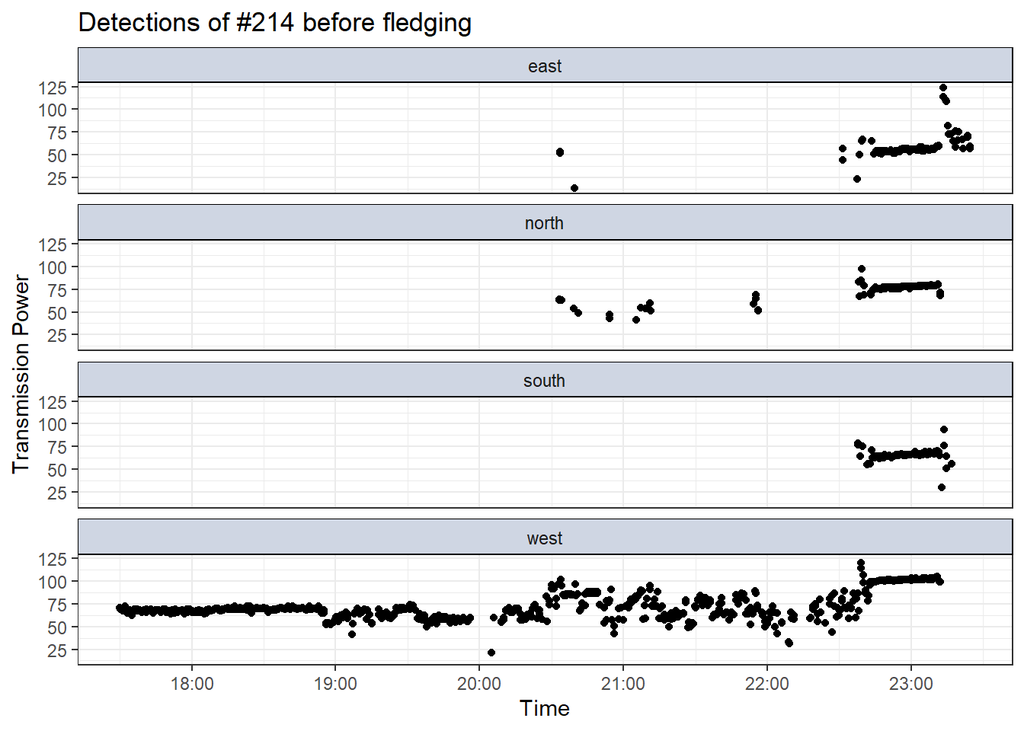

While the bird was still inside its burrow, it was detected at a very consistent power level on the west-facing antenna. Once it emerged from its burrow and started moving around, it started to be detected on other antennas, and the power level of its transmissions became more variable and generally higher. It was then detected very consistently on all four antennas for a while, which might indicate that it was resting somewhere very near the receiver. Then a final spike in transmission power, especially on the south and east-facing antennas, suggests it flew off to the southeast.

We can use these spikes in power to visualize how much time passed between when each fledgling left its burrow for the last time and when it left the island:

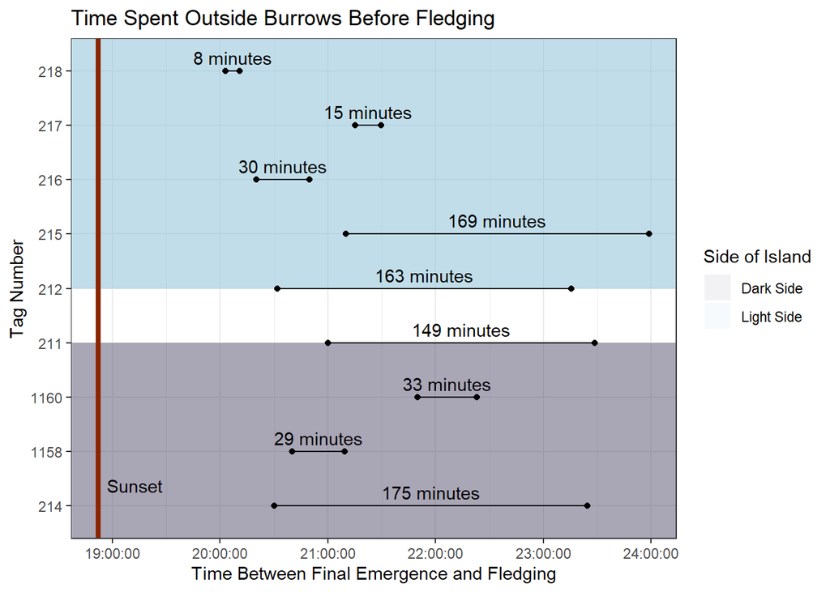

We are hoping to tag 8-10 more fledglings on Gull Island before the end of the season (to use up our extra tags from last year), but that will be the last of the VHF work for this year. I will likely send one more update with more information on fledgling behaviour sometime in early November, once we’ve brought equipment back from the islands and gotten the last of our data. As always, let me know if you have any questions or would like to see any more details!